# Sampling

Diptanshu Singh

Nov 5, 2018

We can use Random Number Generator to sample from distributions. A ‘N’ whole psedo random number generator can be converted into random uniform distributor (0,1), by inversing the number (1/x). We can use this to sample from known distributions. These approxmation methods are used when we can calculate Inverse CDF of the function.

### Closed form Inverse CDF

If you know the cumulative distribution function (CDF) of a probability distribution, then you can always generate a random sample from that distribution. The inverse CDF technique for generating a random sample uses the fact that a continuous CDF, F, is a one-to-one mapping of the domain of the CDF into the interval (0,1). Therefore, if U is a uniform random variable on (0,1), then X = F–1(U) has the distribution F.

Example : Drawing from a Bernouli distribution

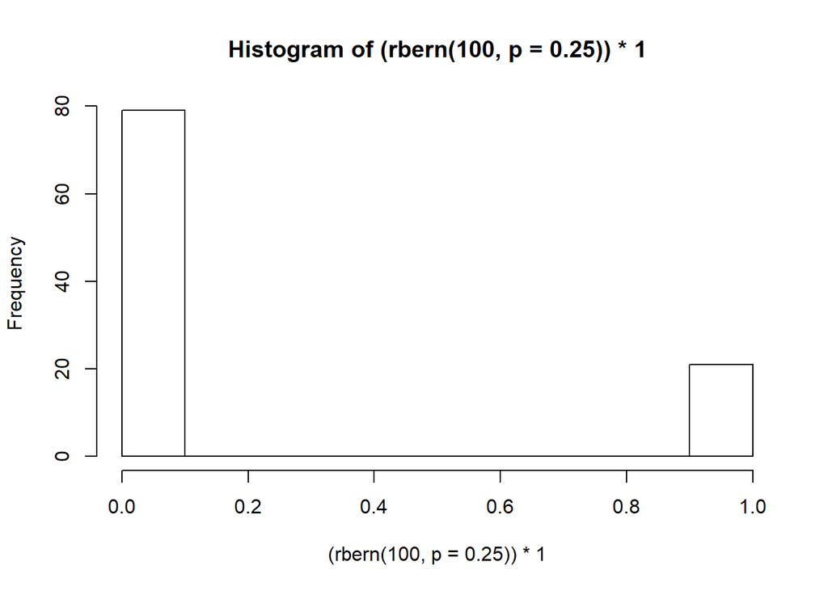

```r
# [ Simulation ]

rbern <- function (n, p = 0.5) runif(n) < p
hist((rbern(100, p=0.25))*1)
```

Example : Drawing from a laplace distribution

```r
# Laplace (double exponential)
rlaplace1 <- function (lambda) {
  u <- runif(2) # U1, U2 ~iid U(0, 1)
  (2 * (u[1] < .5) - 1) * (-log(u[2]) / lambda)
}

# vectorized version
rlaplace <- function (n, lambda = 1)
  (2 * rbern(n) - 1) * (-log(runif(n)) / lambda)
```

### Rejection Sampling

The idea of rejection sampling is that although we cannot easily sample from f , there exists another density g , like a Normal distribution or perhaps a t -distribution, from which it is easy for us to sample (because there’s a built in function or someone else wrote a nice function). Then we can sample from g directly and then “reject” the samples in a strategic way to make the resulting “non-rejected” samples look like they came from f. The density g is called “candidate density” and f will be the “target density”.

Example : Target Density : Semi Circle  
Candidate density : Rectangle with x between -1,1 and y between 0,1

```r
# Wigner's semi-circle
rwigner <- function () {
  repeat {
    x <- 2 * runif(1) -1 # X ~ U(-1, 1)
    u <- runif(1)
    if (x * x + u * u < 1) return(x)
  }
}
```

Example : Target Density : Circle  
Candidate density : Rectangle with x between -1,1 and y between -1,1

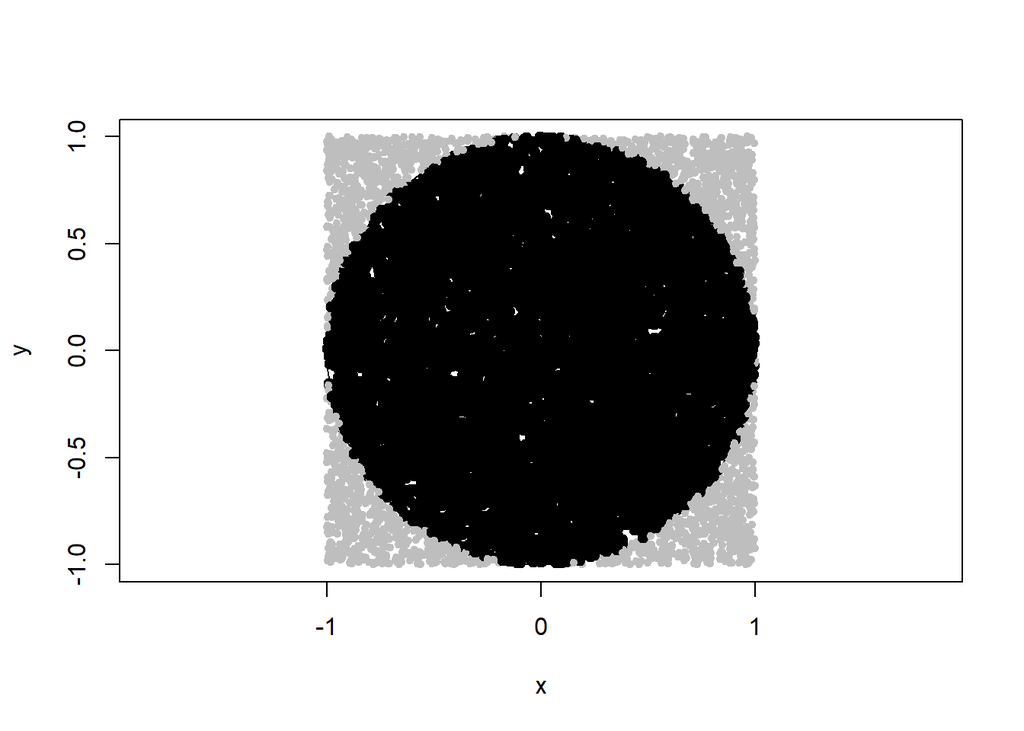

```r
# Uniform in unit circle
rcircle <- function () {
  repeat {
    x <- 2 * runif(2) - 1 # U((-1, 1)^2)
    if (crossprod(x) < 1) return(x)
  }
}

# demo: rcircle
n <- 10000
plot(NA, type = 'n', xlim = c(-1, 1), ylim = c(-1, 1),
     xlab = 'x', ylab = 'y', asp = 1)
t <- seq(0, 2 * pi, length = 100); lines(cos(t), sin(t)) # boundary
for (i in 1:n) {
  x <- runif(2, -1, 1)
  if (crossprod(x) < 1) # accept?
    points(x[1], x[2], pch = 19)
  else
    points(x[1], x[2], pch = 20, col = 'gray')
}
```

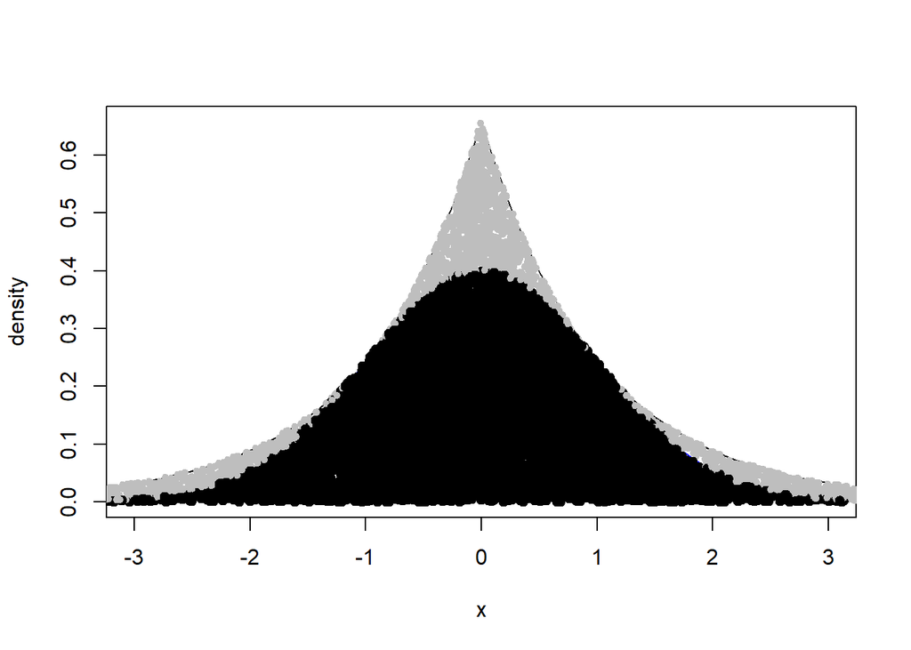

```r
rsnorm1 <- function () {
  repeat {
    x <- -log(runif(1)) # X ~ Exp(1)
    if (log(runif(1)) < -.5 * (x - 1) ^ 2) break
  }
  (2 * rbern(1) - 1) * x
}

Mg <- local({
  M <- exp(.5) / sqrt(2 * pi)
  function (x) M * exp(-x)
})

# demo: rsnorm1
n <- 10000
x <- seq(-3, 3, length.out = 100)
plot(x, Mg(abs(x)), type = 'l',
     ylim = c(0, exp(.5) / sqrt(2 * pi)),
     xlab = 'x', ylab = 'density')
lines(x, dnorm(x), col = 'blue')
for (i in 1:n) {
  s <- 2 * rbern(1) - 1
  x <- -log(runif(1)) # X ~ Exp(1)
  u <- runif(1)
  if (log(u) < -.5 * (x - 1) ^ 2) # accept?
    points(s * x, u * Mg(x), pch = 19)
  else
    points(s * x, u * Mg(x), pch = 20, col = 'gray')
}
```

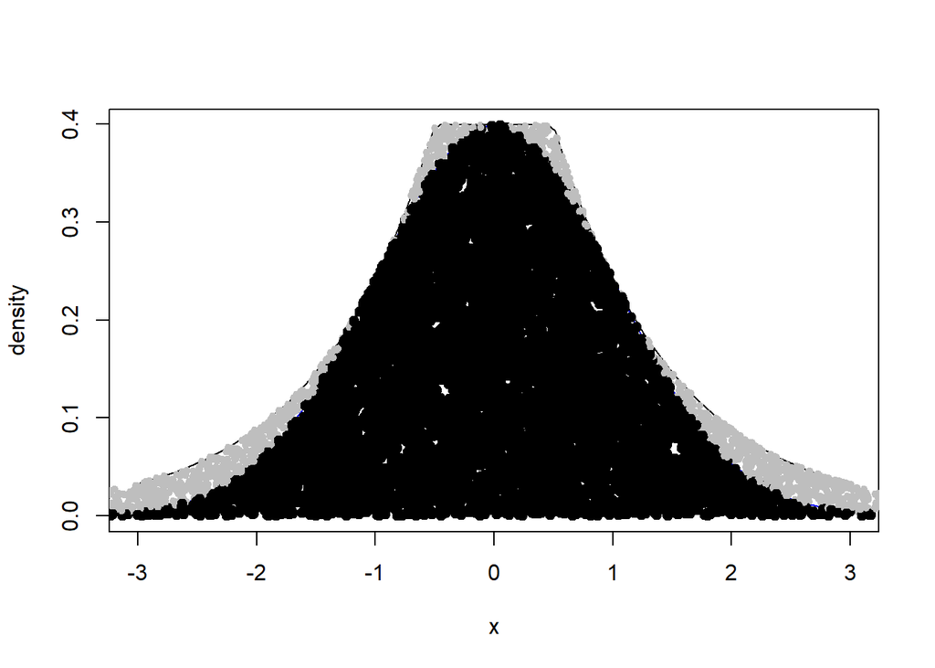

```r
rsnorm2 <- local({
  lambda <- 1 / 3 # prob of body
  function () {
    repeat {
      if (rbern(1, lambda)) { # body?
        x <- .5 * runif(1) # X ~ U(0, .5)
        if (log(runif(1)) < -.5 * x ^ 2) break
      }
      else { # tail
        x <- -log(runif(1)) + .5 # X ~ Exp(1) + .5
        if (log(runif(1)) < -.5 * (x - 1) ^ 2) break
      }
    }
    (2 * rbern(1) - 1) * x
  }
})

# demo: rsnorm2
n <- 10000
x <- seq(-3, 3, length.out = 100)
A <- 1 / sqrt(2 * pi) # ceiling
lambda <- 1 / 3 # prob of body
plot(x, ifelse(abs(x) < .5, A, Mg(abs(x))),
     type = 'l', ylim = c(0, A),
     xlab = 'x', ylab = 'density')
lines(x, dnorm(x), col = 'blue')
for (i in 1:n) {
  s <- 2 * rbinom(1, 1, .5) - 1
  u <- runif(1)
  if (runif(1) < lambda) { # body?
    x <- .5 * runif(1) # X ~ U(0, .5)
    if (log(u) < -.5 * x ^ 2) # accept?
      points(s * x, u * A, pch = 19)
    else
      points(s * x, u * A, pch = 20, col = 'gray')
  }
  else { # tail
    x <- -log(runif(1)) + .5 # X ~ Exp(1) + .5
    if (log(u) < -.5 * (x - 1) ^ 2) # accept?
      points(s * x, u * Mg(x), pch = 19)
    else
      points(s * x, u * Mg(x), pch = 20, col = 'gray')
  }
}
```

### Importance Sampling

Importance sampling is also very useful when we donot want to sample the entire distribution, but are only interested in one particular statistics, such as mean or median.

Problem : Here we are estimating density given by I = int_0^1 cos(pi * x)^2 * exp(-10*x)

```r
n <- 10000

# naive Monte Carlo
h.naive <- function (x) cos(pi * x) ^ 2 * exp(-10 * x)
sn <- h.naive(runif(n))
print(c(mean(sn), sd(sn) / sqrt(n)))
```

```
## [1] 0.082014363 0.001919574
```

```r
# better density for MC
A <- 1 - exp(-10) # P(X < 1), X ~ Exp(10)
h.is <- function (x) cos(pi * x) ^ 2 / 10 * A
si <- h.is(pmin(rexp(n, 10), 1))
print(c(mean(si), sd(si) / sqrt(n)))
```

```
## [1] 0.0856972783 0.0002128144
```

```r
print(sd(sn) / sd(si))
```

```
## [1] 9.019945
```

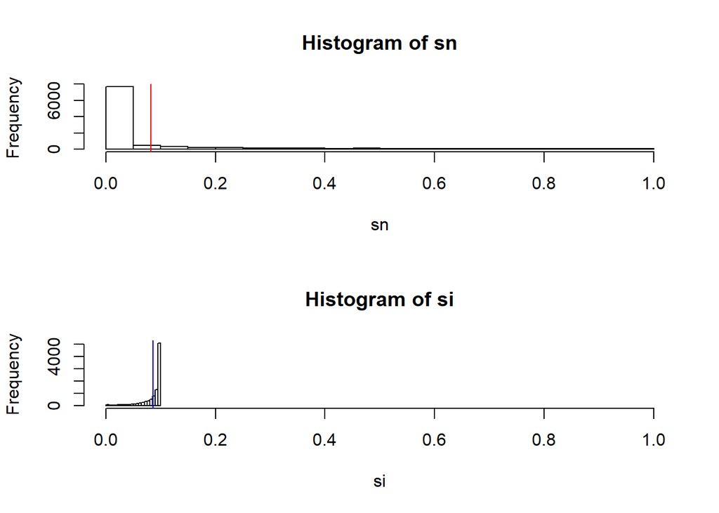

```r
# We see that the standard deviation for importance sampling is 9 times less than native monte carlo


op <- par(mfrow=c(2,1))
hist(sn, xlim=c(0,1)); abline(v=mean(sn), col='red')
hist(si, xlim=c(0,1)); abline(v=mean(si), col='blue')
```

```r
par(op)
```

Since there is no free lunch, we need to calculate an importance weight parameter whenever we do importance sampling. This expression may be very difficult to calculate if f is not know properly, or cannot be expressed properly. This may be easy as in the below case.

```r
# [ network reliability ]

# Erdos-Renyi square lattice:
D <- 3 # lattice dimension
er.lattice <- local({
  L <- make_lattice(c(D, D))
  ne <- ecount(L)
  function (p) {
    x <- rbinom(ne, 1, p) # edges
    subgraph.edges(L, which(x == 1), delete.vertices=FALSE)
  }
})

# importance sampling
p <- .99
n <- 100000

# naive Monte Carlo
hn <- function (px)
  !is_connected(er.lattice(px))
sn <- as.numeric(replicate(n, hn(p)))
print(c(mean(sn), sd(sn)/sqrt(n)))
```

```
## [1] 4.600000e-04 6.780804e-05
```

```r
# importance sampling
pp <- .8
hi <- function (px, p) {
  g <- er.lattice(px)
  ne <- ecount(g)
  nl <- 2 * D * (D - 1) # #edges in full lattice
  iw <- (p / px) ^ ne * ((1 - p) / (1 - px)) ^ (nl - ne) # imp. weight
  (!is_connected(g)) * iw
}
si <- replicate(n, hi(pp, p))
print(c(mean(si), sd(si) / sqrt(n)))
```

```
## [1] 4.194984e-04 8.695170e-06
```

```r
print(sd(sn) / sd(si))
```

```
## [1] 7.798357
```

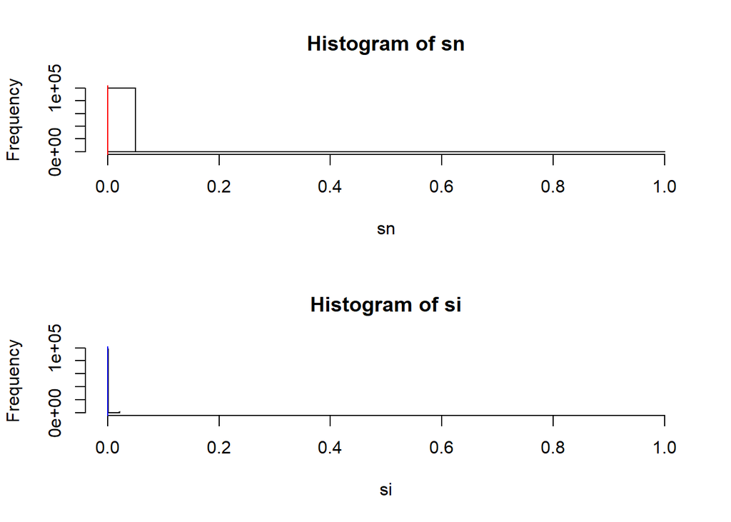

```r
# Standard deviation is 7 times less

op <- par(mfrow=c(2,1))
hist(sn, xlim=range(sn, si)); abline(v=mean(sn), col='red')
hist(si, xlim=range(sn, si)); abline(v=mean(si), col='blue')
```

```r
par(op)
```